# Random Variables and Probability Distributions

```python
import numpy as np, pandas as pd, scipy.stats as ss
import matplotlib.pyplot as plt
%matplotlib inline
```

**Compute Probabilities:** First, we'd like to create a Normal distribution of mean 0.05 and standard deviation 0.1, then compute the following probabilities.

```python
x=ss.norm(0.05,0.1)

mu_x=x.mean()
sigma_x=x.std()

#Pr(x>0.01)
1-ss.norm.cdf(0.1,loc=mu_x,scale=sigma_x)

#Pr(x<-0.1)
ss.norm.cdf(-0.1,loc=mu_x,scale=sigma_x)

#Pr(-0.05>x>0.15)
ss.norm.cdf(0.15,loc=mu_x,scale=sigma_x)-ss.norm.cdf(-0.05,loc=mu_x,scale=sigma_x)
```

```
0.68268949213708585
```

**Compute Quantiles:** Compute the quantiles of the Normal distribution for 1%, 5%, 95% and 99%. We can throw them all into a numpy array, and pass them into scipy.stats.norm.ppf using mu_x and sigma_x from before.

```python
ss.norm.ppf(np.array([0.01,0.05,0.95,0.99]),loc=mu_x,scale=sigma_x)
```

```
array([-0.18263479, -0.11448536,  0.21448536,  0.28263479])
```

**Compute Densities:** Create two distributions of stocks, MSFT and SBUX. Let monthly returns be $\text{MSFT}=X\sim N(0.05,0.1^2)$ and $\text{SBUX}=Y \sim N(0.025,0.05^2)$.

```python
x_vals = np.linspace(-0.25, 0.35,  100)

MSFT=ss.norm.pdf(x_vals,loc=0.05,scale=0.1)
SBUX=ss.norm.pdf(x_vals,loc=0.025,scale=0.05)
```

**Plot the PDFs**

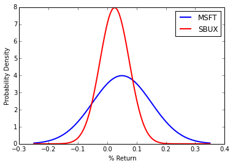

```python
plt.plot(x_vals,MSFT,linewidth=2,c='b')
plt.plot(x_vals,SBUX,linewidth=2,c='r')
plt.legend(['MSFT','SBUX'])
plt.xlabel('% Return')
plt.ylabel('Probability Density')
```

**Determine Value at Risk of simple monthly returns:** Let $\text{MSFT}=X\sim N(0.04,0.09^2)$, and let our principal investment be $100K.

```python
X=ss.norm(0.04,0.09)
mu_R=X.mean()
sigma_R=X.std()

W0=100000

# %1 at value risk
R01=ss.norm.ppf(0.01,mu_R,sigma_R)
W0*R01

#%5 at value risk
R05=ss.norm.ppf(0.05,mu_R,sigma_R)
W0*R05
```

```
-10803.682642563253
```

**Determine the Value at Risk for continuously compounded returns:**

```python
#continuous distribution of return parameters
mu_r = 0.04
sigma_r =0.09

# Initial wealth W0 equals $100,000
W0 = 100000

# The 1% value-at-risk
r01=ss.norm.ppf(0.01,mu_r,sigma_r)
R01=np.exp(r01)-1
W0*R01
# The 5% value-at-risk
r05=ss.norm.ppf(0.05,mu_r,sigma_r)
R05=np.exp(r05)-1
W0*R05
```

```
-10240.545937682344
```

**Compute Simple Monthly Returns:** Take Amazon and Costco month-end prices for Sept and Oct 2004, and compute simple returns.

```python
# Vectors of prices
PA = np.array([38.23,41.29])
PC = np.array([41.11,41.74])

#Compute the simple monthly return

RA = (PA[1]-PA[0])/PA[0]
RC = (PC[1]-PC[0])/PC[0]
```

**Convert to Continuously Compounded Returns:**

```python
rA = np.log(1+RA)
rC=np.log(1+RC)
```

**Compute simple total returns and dividend yields:** Amazon paid $0.1 dividend return at the end of Oct 2004. Compute the Total return and dividend yield.

```python
#10 cent dividend
DA=0.1
RA_Total=(PA[1]+DA-PA[0])/PA[0] #add the dividend onto our monthly return
DY=DA/PA[0] #compute thh dividend yield
```

**Compute Annual Return from monthly return:** \begin{equation} R_{annual} =(1+RA)^{12} - 1 \end{equation} Then compute continuously compounded return.

```python
RA_annual = (1+RA)**12 -1
rA_annual = np.log(RA_annual)
```

**Compute Portfolio returns:** We have \$ 10K and invest \$8K in Amazon, and \$2K in Costco. What are our returns after one month?

```python
#compute the fraction of portfolio invested in each equity
x_A=8000/10000.0
x_C=2000/10000.0

#now compute the portfolio return

x_A*RA+x_C*RC
```

```
0.067098429260274373
```